# marketing

## Business Problem

### The problem here is figuring out how to group the bank's customers into different categories so that the bank can run better and more focused marketing campaigns. The bank has a lot of data about how customers use their credit cards, how much they spend, and how they make payments. The idea is to use this data to find distinct groups of customers who behave in similar ways. By understanding these groups, the bank can learn what different types of customers need and prefer. This will help the marketing team create more personalized ads and offers that speak directly to each group, making customers more engaged, increasing sales, and using marketing budgets more wisely.

## Importing Libraries

```python
import pandas as pd
import numpy as np
import seaborn as sns
import matplotlib.pyplot as plt
from sklearn.preprocessing import StandardScaler, normalize
from sklearn.cluster import KMeans
from sklearn.decomposition import PCA
```

## Loading the Dataset

```python
df = pd.read_csv('Marketing_data.csv')
df.head()
```

|  | CUST_ID | BALANCE | BALANCE_FREQUENCY | PURCHASES | ONEOFF_PURCHASES | INSTALLMENTS_PURCHASES | CASH_ADVANCE | PURCHASES_FREQUENCY | ONEOFF_PURCHASES_FREQUENCY | PURCHASES_INSTALLMENTS_FREQUENCY | CASH_ADVANCE_FREQUENCY | CASH_ADVANCE_TRX | PURCHASES_TRX | CREDIT_LIMIT | PAYMENTS | MINIMUM_PAYMENTS | PRC_FULL_PAYMENT | TENURE |
| --- | --- | --- | --- | --- | --- | --- | --- | --- | --- | --- | --- | --- | --- | --- | --- | --- | --- | --- |
| 0 | C10001 | 40.900749 | 0.818182 | 95.40 | 0.00 | 95.4 | 0.000000 | 0.166667 | 0.000000 | 0.083333 | 0.000000 | 0 | 2 | 1000.0 | 201.802084 | 139.509787 | 0.000000 | 12 |
| 1 | C10002 | 3202.467416 | 0.909091 | 0.00 | 0.00 | 0.0 | 6442.945483 | 0.000000 | 0.000000 | 0.000000 | 0.250000 | 4 | 0 | 7000.0 | 4103.032597 | 1072.340217 | 0.222222 | 12 |
| 2 | C10003 | 2495.148862 | 1.000000 | 773.17 | 773.17 | 0.0 | 0.000000 | 1.000000 | 1.000000 | 0.000000 | 0.000000 | 0 | 12 | 7500.0 | 622.066742 | 627.284787 | 0.000000 | 12 |
| 3 | C10004 | 1666.670542 | 0.636364 | 1499.00 | 1499.00 | 0.0 | 205.788017 | 0.083333 | 0.083333 | 0.000000 | 0.083333 | 1 | 1 | 7500.0 | 0.000000 | NaN | 0.000000 | 12 |
| 4 | C10005 | 817.714335 | 1.000000 | 16.00 | 16.00 | 0.0 | 0.000000 | 0.083333 | 0.083333 | 0.000000 | 0.000000 | 0 | 1 | 1200.0 | 678.334763 | 244.791237 | 0.000000 | 12 |

```python
df.shape
```

```
(8950, 18)
```

## **Descritpion of features**

**CUSTID**: *Unique identifier for a credit card customer*  
**BALANCE**: *Remaining balance in the customer’s account available for transactions*  
**BALANCE_FREQUENCY**: *Frequency with which the balance is updated, with a value between 0 and 1 (1 = frequently updated, 0 = rarely updated)*  
**PURCHASES**: *Total amount spent on purchases using the account*  
**ONEOFFPURCHASES**: *Highest single transaction amount made in a single purchase*  
**INSTALLMENTS_PURCHASES**: *Total amount spent on purchases made in installments*  
**CASH_ADVANCE**: *Amount of cash taken in advance by the customer*  
**PURCHASES_FREQUENCY**: *Rate at which purchases are made, scored between 0 and 1 (1 = frequent purchases, 0 = infrequent purchases)*  
**ONEOFF_PURCHASES_FREQUENCY**: *Rate at which one-time purchases occur (1 = frequent, 0 = infrequent)*  
**PURCHASES_INSTALLMENTS_FREQUENCY**: *Frequency of purchases made in installments (1 = frequent, 0 = infrequent)*  
**CASH_ADVANCE_FREQUENCY**: *How often cash advances are utilized*  
**CASH_ADVANCE_TRX**: *Number of transactions where cash advance was used*  
**PURCHASES_TRX**: *Number of transactions made for purchases*  
**CREDIT_LIMIT**: *The credit limit assigned to the user*  
**PAYMENTS**: *Total amount paid by the customer*  
**MINIMUM_PAYMENTS**: *Minimum amount required to be paid by the customer*  
**PRC_FULL_PAYMENT**: *Percentage of the total bill paid in full by the customer*  
**TENURE**: *Duration of time the customer has held the credit card*

## Dataset Exploration

```python
df.info()
```

```
<class 'pandas.core.frame.DataFrame'>
RangeIndex: 8950 entries, 0 to 8949
Data columns (total 18 columns):
 #   Column                            Non-Null Count  Dtype
---  ------                            --------------  -----
 0   CUST_ID                           8950 non-null   object
 1   BALANCE                           8950 non-null   float64
 2   BALANCE_FREQUENCY                 8950 non-null   float64
 3   PURCHASES                         8950 non-null   float64
 4   ONEOFF_PURCHASES                  8950 non-null   float64
 5   INSTALLMENTS_PURCHASES            8950 non-null   float64
 6   CASH_ADVANCE                      8950 non-null   float64
 7   PURCHASES_FREQUENCY               8950 non-null   float64
 8   ONEOFF_PURCHASES_FREQUENCY        8950 non-null   float64
 9   PURCHASES_INSTALLMENTS_FREQUENCY  8950 non-null   float64
 10  CASH_ADVANCE_FREQUENCY            8950 non-null   float64
 11  CASH_ADVANCE_TRX                  8950 non-null   int64
 12  PURCHASES_TRX                     8950 non-null   int64
 13  CREDIT_LIMIT                      8949 non-null   float64
 14  PAYMENTS                          8950 non-null   float64
 15  MINIMUM_PAYMENTS                  8637 non-null   float64
 16  PRC_FULL_PAYMENT                  8950 non-null   float64
 17  TENURE                            8950 non-null   int64
dtypes: float64(14), int64(3), object(1)
memory usage: 1.2+ MB
```

```python
df.describe()
```

|  | BALANCE | BALANCE_FREQUENCY | PURCHASES | ONEOFF_PURCHASES | INSTALLMENTS_PURCHASES | CASH_ADVANCE | PURCHASES_FREQUENCY | ONEOFF_PURCHASES_FREQUENCY | PURCHASES_INSTALLMENTS_FREQUENCY | CASH_ADVANCE_FREQUENCY | CASH_ADVANCE_TRX | PURCHASES_TRX | CREDIT_LIMIT | PAYMENTS | MINIMUM_PAYMENTS | PRC_FULL_PAYMENT | TENURE |
| --- | --- | --- | --- | --- | --- | --- | --- | --- | --- | --- | --- | --- | --- | --- | --- | --- | --- |
| count | 8950.000000 | 8950.000000 | 8950.000000 | 8950.000000 | 8950.000000 | 8950.000000 | 8950.000000 | 8950.000000 | 8950.000000 | 8950.000000 | 8950.000000 | 8950.000000 | 8949.000000 | 8950.000000 | 8637.000000 | 8950.000000 | 8950.000000 |
| mean | 1564.474828 | 0.877271 | 1003.204834 | 592.437371 | 411.067645 | 978.871112 | 0.490351 | 0.202458 | 0.364437 | 0.135144 | 3.248827 | 14.709832 | 4494.449450 | 1733.143852 | 864.206542 | 0.153715 | 11.517318 |
| std | 2081.531879 | 0.236904 | 2136.634782 | 1659.887917 | 904.338115 | 2097.163877 | 0.401371 | 0.298336 | 0.397448 | 0.200121 | 6.824647 | 24.857649 | 3638.815725 | 2895.063757 | 2372.446607 | 0.292499 | 1.338331 |
| min | 0.000000 | 0.000000 | 0.000000 | 0.000000 | 0.000000 | 0.000000 | 0.000000 | 0.000000 | 0.000000 | 0.000000 | 0.000000 | 0.000000 | 50.000000 | 0.000000 | 0.019163 | 0.000000 | 6.000000 |
| 25% | 128.281915 | 0.888889 | 39.635000 | 0.000000 | 0.000000 | 0.000000 | 0.083333 | 0.000000 | 0.000000 | 0.000000 | 0.000000 | 1.000000 | 1600.000000 | 383.276166 | 169.123707 | 0.000000 | 12.000000 |
| 50% | 873.385231 | 1.000000 | 361.280000 | 38.000000 | 89.000000 | 0.000000 | 0.500000 | 0.083333 | 0.166667 | 0.000000 | 0.000000 | 7.000000 | 3000.000000 | 856.901546 | 312.343947 | 0.000000 | 12.000000 |
| 75% | 2054.140036 | 1.000000 | 1110.130000 | 577.405000 | 468.637500 | 1113.821139 | 0.916667 | 0.300000 | 0.750000 | 0.222222 | 4.000000 | 17.000000 | 6500.000000 | 1901.134317 | 825.485459 | 0.142857 | 12.000000 |
| max | 19043.138560 | 1.000000 | 49039.570000 | 40761.250000 | 22500.000000 | 47137.211760 | 1.000000 | 1.000000 | 1.000000 | 1.500000 | 123.000000 | 358.000000 | 30000.000000 | 50721.483360 | 76406.207520 | 1.000000 | 12.000000 |

Here are some general observations about the dataset:

For BALANCE, the average balance is about 1564.47. The balances of customers are quite different from each other, shown by a high standard deviation of 2081.53. The lowest balance is 0, and the highest is around 19,043.14, which means there’s a big range of balances.

For BALANCE_FREQUENCY, the average is around 0.88. This tells us that most customers regularly maintain their balance. The median is 1, which means at least half of the customers always keep their balance.

Looking at PURCHASES, the average amount spent is 1003.20, but the numbers vary a lot, as the standard deviation is 2136.63. The highest amount spent is very high, at 49,039.57, which might mean there are some customers who spend a lot.

For ONEOFF_PURCHASES and INSTALLMENTS_PURCHASES, the average for one-off purchases is 592.44, and the highest is 40,761.25. Installment purchases have an average of 411.07, with the highest being 22,500. This means some customers are making big purchases either in one go or in installments.

For the FREQUENCY COLUMNS (like PURCHASES_FREQUENCY, ONEOFF_PURCHASES_FREQUENCY, etc.), the values are between 0 and 1, showing how often different activities happen (like purchases, one-off purchases, etc.). For example, the average purchases frequency is 0.49, meaning that, on average, purchases happen about half the time.

For CREDIT_LIMIT, the average is 4494.45, but it changes a lot across customers, with a standard deviation of 3638.82. The smallest credit limit is 50, and the largest is 30,000.

Looking at PAYMENTS, the average payment is 1733.14, but there's a big spread, with a standard deviation of 2895.06. The lowest payment is 0, and the highest recorded payment is 50,721.48.

For MINIMUM_PAYMENTS, there are some missing values (8637 out of 8950 are available), so that needs to be handled. The average minimum payment is 864.21, but there's a lot of variation with a standard deviation of 2372.45.

Lastly, for TENURE, most customers have been around for 12 years, with an average of 11.52 and a median of 12, which shows that many customers have been with the company for many years.

Here are some thoughts on customer segmentation and behavior:

The big differences and high standard deviations in things like purchases, payments, and credit limits suggest that there could be different types of customers. For example, there might be high spenders who make big purchases often, or those who frequently take out cash advances.

When it comes to risk assessment, the large variability in cash advances and payments could be a sign of customers who might be more risky. Customers who often take big cash advances or have irregular payments might be considered higher risk.

Looking at behavioral patterns, the frequency columns (like how often customers make purchases or take cash advances) can give us a good idea of how customers behave. Some customers might make regular purchases, while others might use cash advances more often. This can help in understanding their habits and possibly predicting future behavior.

Let's at two customers to see how they behave in extreme ways. One of them made a really big one-off purchase of $40,000, which means they like using their card for big stuff but don't really use cash advances. The other customer, though, took out $47,000 in cash advances, which shows they prefer getting cash rather than buying things with the card. By checking them out, we can figure out what kind of products or offers would work best for each of them.

```python
df[df['ONEOFF_PURCHASES'] == 40761.25]
```

|  | CUST_ID | BALANCE | BALANCE_FREQUENCY | PURCHASES | ONEOFF_PURCHASES | INSTALLMENTS_PURCHASES | CASH_ADVANCE | PURCHASES_FREQUENCY | ONEOFF_PURCHASES_FREQUENCY | PURCHASES_INSTALLMENTS_FREQUENCY | CASH_ADVANCE_FREQUENCY | CASH_ADVANCE_TRX | PURCHASES_TRX | CREDIT_LIMIT | PAYMENTS | MINIMUM_PAYMENTS | PRC_FULL_PAYMENT | TENURE |
| --- | --- | --- | --- | --- | --- | --- | --- | --- | --- | --- | --- | --- | --- | --- | --- | --- | --- | --- |
| 550 | C10574 | 11547.52001 | 1.0 | 49039.57 | 40761.25 | 8278.32 | 558.166886 | 1.0 | 1.0 | 0.916667 | 0.083333 | 1 | 101 | 22500.0 | 46930.59824 | 2974.069421 | 0.25 | 12 |

```python
df['CASH_ADVANCE'].max()
```

```
np.float64(47137.21176)
```

```python
df[df['CASH_ADVANCE'] == 47137.21176]
```

|  | CUST_ID | BALANCE | BALANCE_FREQUENCY | PURCHASES | ONEOFF_PURCHASES | INSTALLMENTS_PURCHASES | CASH_ADVANCE | PURCHASES_FREQUENCY | ONEOFF_PURCHASES_FREQUENCY | PURCHASES_INSTALLMENTS_FREQUENCY | CASH_ADVANCE_FREQUENCY | CASH_ADVANCE_TRX | PURCHASES_TRX | CREDIT_LIMIT | PAYMENTS | MINIMUM_PAYMENTS | PRC_FULL_PAYMENT | TENURE |
| --- | --- | --- | --- | --- | --- | --- | --- | --- | --- | --- | --- | --- | --- | --- | --- | --- | --- | --- |
| 2159 | C12226 | 10905.05381 | 1.0 | 431.93 | 133.5 | 298.43 | 47137.21176 | 0.583333 | 0.25 | 0.5 | 1.0 | 123 | 21 | 19600.0 | 39048.59762 | 5394.173671 | 0.0 | 12 |

Customer with the biggest one-off purchase spent around $40,761.25 in a single transaction, likely on something big like a car. His/her balance is about $11,000, and often use their card for large purchases but hardly ever take cash advances. This suggests he/she might be more interested in offers related to big purchases or installment plans rather than cash advances.

On the other hand, the customer with the highest cash advance took out $47,137.21. His/her balance is around $10,905, and don’t spend much on regular purchases but frequently rely on cash advances, with 123 transactions. This might mean he/she need quick access to cash, so he/she could benefit from products focused on liquidity or lower interest rates on cash advances.

Looking at these two customers helps to understand different spending habits. One prefers big one-off purchases, while the other depends on cash advances, allowing for better-targeted marketing and product offerings.

```python
df.isnull().sum()
```

```
CUST_ID                               0
BALANCE                               0
BALANCE_FREQUENCY                     0
PURCHASES                             0
ONEOFF_PURCHASES                      0
INSTALLMENTS_PURCHASES                0
CASH_ADVANCE                          0
PURCHASES_FREQUENCY                   0
ONEOFF_PURCHASES_FREQUENCY            0
PURCHASES_INSTALLMENTS_FREQUENCY      0
CASH_ADVANCE_FREQUENCY                0
CASH_ADVANCE_TRX                      0
PURCHASES_TRX                         0
CREDIT_LIMIT                          1
PAYMENTS                              0
MINIMUM_PAYMENTS                    313
PRC_FULL_PAYMENT                      0
TENURE                                0
dtype: int64
```

There are 1 missing data point in CREDIT_LIMIT and 313 missing data points in MINIMUM_PAYMENTS. Let's handle them, by reaplacing them with median value.

Based on the high standard deviations observed in columns like CREDIT_LIMIT and MINIMUM_PAYMENTS, it is likely that these columns have a skewed distribution or contain outliers. Thus, it would be safer to fill missing values using the median. But its more better to check distribution of these features to decide between median or mean with surety.

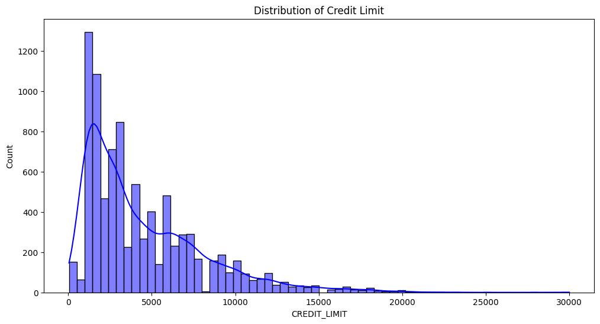

```python
plt.figure(figsize=(12,6))
plt.title("Distribution of Credit Limit")
sns.histplot(df['CREDIT_LIMIT'], color='blue', kde=True)
plt.show()
```

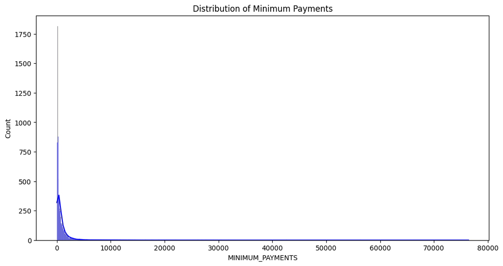

```python
plt.figure(figsize=(12,6))
plt.title("Distribution of Minimum Payments")
sns.histplot(df['MINIMUM_PAYMENTS'], color='blue', kde=True)
plt.show()
```

So its is confirmd that these two features are highly right skewed so it's better to use median

```python
df['CREDIT_LIMIT'] = df['CREDIT_LIMIT'].fillna(df['CREDIT_LIMIT'].median())
df['MINIMUM_PAYMENTS'] = df['MINIMUM_PAYMENTS'].fillna(df['MINIMUM_PAYMENTS'].median())
```

```python
df.isnull().sum()
```

```
CUST_ID                             0
BALANCE                             0
BALANCE_FREQUENCY                   0
PURCHASES                           0
ONEOFF_PURCHASES                    0
INSTALLMENTS_PURCHASES              0
CASH_ADVANCE                        0
PURCHASES_FREQUENCY                 0
ONEOFF_PURCHASES_FREQUENCY          0
PURCHASES_INSTALLMENTS_FREQUENCY    0
CASH_ADVANCE_FREQUENCY              0
CASH_ADVANCE_TRX                    0
PURCHASES_TRX                       0
CREDIT_LIMIT                        0
PAYMENTS                            0
MINIMUM_PAYMENTS                    0
PRC_FULL_PAYMENT                    0
TENURE                              0
dtype: int64
```

Let's drop CUST_ID column , becuase it of no use.

```python
df = df.drop('CUST_ID', axis=1)
```

```python
df.head()
```

|  | BALANCE | BALANCE_FREQUENCY | PURCHASES | ONEOFF_PURCHASES | INSTALLMENTS_PURCHASES | CASH_ADVANCE | PURCHASES_FREQUENCY | ONEOFF_PURCHASES_FREQUENCY | PURCHASES_INSTALLMENTS_FREQUENCY | CASH_ADVANCE_FREQUENCY | CASH_ADVANCE_TRX | PURCHASES_TRX | CREDIT_LIMIT | PAYMENTS | MINIMUM_PAYMENTS | PRC_FULL_PAYMENT | TENURE |
| --- | --- | --- | --- | --- | --- | --- | --- | --- | --- | --- | --- | --- | --- | --- | --- | --- | --- |
| 0 | 40.900749 | 0.818182 | 95.40 | 0.00 | 95.4 | 0.000000 | 0.166667 | 0.000000 | 0.083333 | 0.000000 | 0 | 2 | 1000.0 | 201.802084 | 139.509787 | 0.000000 | 12 |
| 1 | 3202.467416 | 0.909091 | 0.00 | 0.00 | 0.0 | 6442.945483 | 0.000000 | 0.000000 | 0.000000 | 0.250000 | 4 | 0 | 7000.0 | 4103.032597 | 1072.340217 | 0.222222 | 12 |
| 2 | 2495.148862 | 1.000000 | 773.17 | 773.17 | 0.0 | 0.000000 | 1.000000 | 1.000000 | 0.000000 | 0.000000 | 0 | 12 | 7500.0 | 622.066742 | 627.284787 | 0.000000 | 12 |
| 3 | 1666.670542 | 0.636364 | 1499.00 | 1499.00 | 0.0 | 205.788017 | 0.083333 | 0.083333 | 0.000000 | 0.083333 | 1 | 1 | 7500.0 | 0.000000 | 312.343947 | 0.000000 | 12 |
| 4 | 817.714335 | 1.000000 | 16.00 | 16.00 | 0.0 | 0.000000 | 0.083333 | 0.083333 | 0.000000 | 0.000000 | 0 | 1 | 1200.0 | 678.334763 | 244.791237 | 0.000000 | 12 |

Let's check for duplica rows.

```python
df.duplicated().sum()
```

```
np.int64(0)
```

Now let's visualize distribution of all the columns.

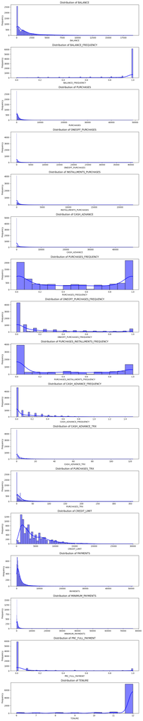

```python
plt.figure(figsize=(10,50))
for i in range(len(df.columns)):
  plt.subplot(17, 1, i+1)
  sns.histplot(df[df.columns[i]], kde=True, color='blue',line_kws={"lw": 2})
  plt.title(f"Distribution of {df.columns[i]}")
  plt.xlabel(df.columns[i])
  plt.ylabel("Frequency")
plt.tight_layout()
plt.show()
```

For Balance Frequency, most customers are at 1, which means they keep their balance steady and use their credit cards regularly, making frequent payments or updates.

Looking at One-Off Purchases, most customers don’t make large one-off purchases. They mostly spend small amounts, if at all, on these.

For Installment Purchases, it’s the same story as one-off purchases. Most customers are not spending big amounts on installments.

In the Cash Advance category, most customers hardly use cash advances at all. The amounts are mostly close to zero, but a small group of customers takes out large cash advances.

For Purchases Frequency, there are two main groups of customers: those who use their credit cards for purchases all the time (frequency around 1) and those who don’t use them as often. This shows that customers can be grouped based on how often they make purchases.

For One-Off Purchases Frequency, the chart shows that most people rarely do one-off purchases. This isn’t a common behavior.

The Purchases Installments Frequency is pretty similar to the one-off purchases frequency—most people don’t use installments often.

For Cash Advance Frequency, most customers have a frequency close to zero, so they rarely take out cash advances. This fits with what we saw with cash advance amounts—most people don’t seem to need or want them.

The Cash Advance Transactions (TRX) chart shows most customers have only a few transactions involving cash advances, but a few have a lot.

For Purchases Transactions (TRX), most customers make a moderate number of purchase transactions. Some customers, though, make a lot more.

For Credit Limit, most customers have a limit between $1,000 and $10,000. There aren’t too many people with very high credit limits, so those are less common.

Looking at Payments, most customers pay less than $2,000. However, a few people make really high payments, which stands out.

For Minimum Payments, most people have low minimum payments, but some have very high amounts, making them outliers.

When it comes to Percentage Full Payment (PRC_FULL_PAYMENT), most customers have a low percentage, between 0 and 0.2, meaning they don’t pay their full balance. Only a small number pay their credit card in full.

Finally, for Tenure, most customers have been with the bank for 11 or 12 years. Not many have been there for less than six years, so most customers are pretty loyal and have been around for a long time.

The plots give us a lot of useful information about how customers use their credit cards, and this can help us figure out different groups of customers for targeted offers and products. For example, customers who use their credit cards often or have high balances might like deals on rewards programs or ways to manage their balance better. On the other hand, customers who take a lot of cash advances might be interested in products that offer lower fees or interest rates on cash advances. By understanding these patterns, we can create financial products that fit what different customers need and want.

## Applying K-means Clustering

```python
scaler = StandardScaler()
df_scaled = scaler.fit_transform(df)
```

```python
df_scaled
```

```
array([[-0.73198937, -0.24943448, -0.42489974, ..., -0.3024    ,
        -0.52555097,  0.36067954],
       [ 0.78696085,  0.13432467, -0.46955188, ...,  0.09749953,
         0.2342269 ,  0.36067954],
       [ 0.44713513,  0.51808382, -0.10766823, ..., -0.0932934 ,
        -0.52555097,  0.36067954],
       ...,
       [-0.7403981 , -0.18547673, -0.40196519, ..., -0.32687479,
         0.32919999, -4.12276757],
       [-0.74517423, -0.18547673, -0.46955188, ..., -0.33830497,
         0.32919999, -4.12276757],
       [-0.57257511, -0.88903307,  0.04214581, ..., -0.3243581 ,
        -0.52555097, -4.12276757]])
```

Let's find optimal number of clusters using Elbow Method

```python
score_1 = []
range_values = range(1,20)
for i in range_values:
  kmeans = KMeans(n_clusters=i)
  kmeans.fit(df_scaled)
  score_1.append(kmeans.inertia_)
```

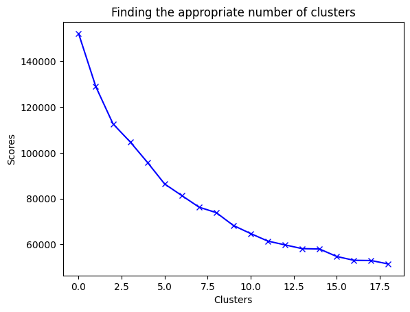

```python
plt.plot(score_1, 'bx-')
plt.title('Finding the appropriate number of clusters')
plt.xlabel('Clusters')
plt.ylabel('Scores')
plt.show()
```

The Elbow Point on the graph is where we see the biggest drop in scores as we add more clusters, which happens from 1 to about 7 clusters. This means that adding more clusters up to 7 really helps to make the groups better by making them tighter and reducing the distance within each group. But after 7 clusters, the scores don't drop as much, and the line starts to flatten out. This creates an "elbow" shape at around 7 clusters.

The "elbow" point is where adding more clusters doesn't really make things much better, so it’s not worth it to keep adding more clusters beyond this point.

The best number of clusters seems to be around 7. This is where the "elbow" is on the graph, showing that 7 clusters give a good balance. It helps make the groups clear without overcomplicating things by having too many clusters that might not be very useful.

Let's continue applying K-means clustering

```python
kmeans = KMeans(7)
kmeans.fit(df_scaled)
labels = kmeans.labels_
```

```python
kmeans.cluster_centers_.shape
```

```
(7, 17)
```

```python
cluster_centers = pd.DataFrame(data = kmeans.cluster_centers_, columns = [df.columns])
cluster_centers
```

|  | BALANCE | BALANCE_FREQUENCY | PURCHASES | ONEOFF_PURCHASES | INSTALLMENTS_PURCHASES | CASH_ADVANCE | PURCHASES_FREQUENCY | ONEOFF_PURCHASES_FREQUENCY | PURCHASES_INSTALLMENTS_FREQUENCY | CASH_ADVANCE_FREQUENCY | CASH_ADVANCE_TRX | PURCHASES_TRX | CREDIT_LIMIT | PAYMENTS | MINIMUM_PAYMENTS | PRC_FULL_PAYMENT | TENURE |
| --- | --- | --- | --- | --- | --- | --- | --- | --- | --- | --- | --- | --- | --- | --- | --- | --- | --- |
| 0 | -0.694395 | 0.090754 | 0.086872 | -0.041380 | 0.281001 | -0.449883 | 0.897157 | 0.245053 | 0.739284 | -0.641563 | -0.459475 | 0.170240 | 0.048425 | -0.151768 | -0.286354 | 2.181470 | -0.098696 |
| 1 | 0.001748 | 0.372665 | -0.365609 | -0.242996 | -0.417934 | -0.055145 | -0.907631 | -0.407690 | -0.805532 | 0.176814 | -0.001423 | -0.500117 | -0.328359 | -0.261537 | -0.024387 | -0.451648 | -0.013991 |
| 2 | 1.923051 | 0.337717 | 11.212042 | 10.600367 | 7.033118 | 0.419625 | 1.046983 | 1.915501 | 0.981334 | -0.258912 | 0.061229 | 5.362438 | 3.044081 | 8.098975 | 1.127533 | 1.110132 | 0.310863 |
| 3 | 1.615263 | 0.377216 | -0.214653 | -0.145053 | -0.241118 | 1.989602 | -0.466261 | -0.171251 | -0.434925 | 1.927680 | 1.896949 | -0.268322 | 0.987185 | 0.776927 | 0.527484 | -0.391009 | -0.088317 |
| 4 | 0.713886 | 0.464549 | 1.992395 | 1.674384 | 1.634849 | -0.216206 | 1.157228 | 1.739439 | 1.070432 | -0.319433 | -0.232845 | 2.352105 | 1.159999 | 1.093622 | 0.305312 | 0.256867 | 0.308309 |
| 5 | -0.695085 | -2.173522 | -0.326612 | -0.242052 | -0.327456 | -0.296768 | -0.586523 | -0.448942 | -0.468625 | -0.469555 | -0.348400 | -0.436376 | -0.242501 | -0.226855 | -0.284946 | 0.067453 | -0.171163 |
| 6 | -0.177452 | 0.385932 | 0.022859 | -0.056522 | 0.157929 | -0.316316 | 0.912691 | 0.236653 | 0.803469 | -0.367523 | -0.305361 | 0.214871 | -0.208187 | -0.179053 | 0.003593 | -0.332269 | 0.102362 |

```python
cluster_centers = scaler.inverse_transform(cluster_centers)
cluster_centers = pd.DataFrame(data = cluster_centers, columns = [df.columns])
cluster_centers
```

|  | BALANCE | BALANCE_FREQUENCY | PURCHASES | ONEOFF_PURCHASES | INSTALLMENTS_PURCHASES | CASH_ADVANCE | PURCHASES_FREQUENCY | ONEOFF_PURCHASES_FREQUENCY | PURCHASES_INSTALLMENTS_FREQUENCY | CASH_ADVANCE_FREQUENCY | CASH_ADVANCE_TRX | PURCHASES_TRX | CREDIT_LIMIT | PAYMENTS | MINIMUM_PAYMENTS | PRC_FULL_PAYMENT | TENURE |
| --- | --- | --- | --- | --- | --- | --- | --- | --- | --- | --- | --- | --- | --- | --- | --- | --- | --- |
| 0 | 119.150057 | 0.898769 | 1188.807927 | 523.755035 | 665.173195 | 35.446401 | 0.850423 | 0.275562 | 0.658248 | 0.006761 | 0.113246 | 18.941355 | 4670.474768 | 1293.790366 | 176.940202 | 0.791757 | 11.385238 |
| 1 | 1568.113840 | 0.965552 | 222.075330 | 189.114192 | 33.134902 | 863.229758 | 0.126074 | 0.080836 | 0.044298 | 0.170527 | 3.239115 | 2.278792 | 3299.566948 | 976.020845 | 788.021208 | 0.021615 | 11.498596 |
| 2 | 5567.142164 | 0.957273 | 24957.905000 | 18186.875667 | 6771.029333 | 1858.844605 | 0.910556 | 0.773889 | 0.754444 | 0.083333 | 3.666667 | 148.000000 | 15570.000000 | 25178.882690 | 3475.059479 | 0.478409 | 11.933333 |
| 3 | 4926.508920 | 0.966630 | 544.595823 | 351.679258 | 193.027437 | 5151.159978 | 0.303218 | 0.151370 | 0.191587 | 0.520893 | 16.194111 | 8.040349 | 8086.100922 | 3982.270217 | 2075.349172 | 0.039351 | 11.399128 |
| 4 | 3050.367871 | 0.987318 | 5259.987675 | 3371.572239 | 1889.441077 | 525.477269 | 0.954802 | 0.721366 | 0.789854 | 0.071222 | 1.659829 | 73.174359 | 8714.871795 | 4899.072798 | 1557.095369 | 0.228844 | 11.929915 |
| 5 | 117.713546 | 0.362383 | 305.393725 | 190.680891 | 114.953158 | 356.534100 | 0.254951 | 0.068529 | 0.178194 | 0.041181 | 0.871255 | 3.863158 | 3611.955016 | 1076.419707 | 180.224561 | 0.173443 | 11.288259 |
| 6 | 1195.122637 | 0.968694 | 1052.044382 | 498.621786 | 553.880524 | 315.540819 | 0.856658 | 0.273056 | 0.683757 | 0.061599 | 1.164962 | 20.050725 | 3736.804318 | 1214.802746 | 853.287384 | 0.056532 | 11.654305 |

```python
df_cluster = pd.concat([df, pd.DataFrame({'cluster':labels})], axis = 1)
df_cluster.head()
```

|  | BALANCE | BALANCE_FREQUENCY | PURCHASES | ONEOFF_PURCHASES | INSTALLMENTS_PURCHASES | CASH_ADVANCE | PURCHASES_FREQUENCY | ONEOFF_PURCHASES_FREQUENCY | PURCHASES_INSTALLMENTS_FREQUENCY | CASH_ADVANCE_FREQUENCY | CASH_ADVANCE_TRX | PURCHASES_TRX | CREDIT_LIMIT | PAYMENTS | MINIMUM_PAYMENTS | PRC_FULL_PAYMENT | TENURE | cluster |
| --- | --- | --- | --- | --- | --- | --- | --- | --- | --- | --- | --- | --- | --- | --- | --- | --- | --- | --- |
| 0 | 40.900749 | 0.818182 | 95.40 | 0.00 | 95.4 | 0.000000 | 0.166667 | 0.000000 | 0.083333 | 0.000000 | 0 | 2 | 1000.0 | 201.802084 | 139.509787 | 0.000000 | 12 | 1 |
| 1 | 3202.467416 | 0.909091 | 0.00 | 0.00 | 0.0 | 6442.945483 | 0.000000 | 0.000000 | 0.000000 | 0.250000 | 4 | 0 | 7000.0 | 4103.032597 | 1072.340217 | 0.222222 | 12 | 3 |
| 2 | 2495.148862 | 1.000000 | 773.17 | 773.17 | 0.0 | 0.000000 | 1.000000 | 1.000000 | 0.000000 | 0.000000 | 0 | 12 | 7500.0 | 622.066742 | 627.284787 | 0.000000 | 12 | 6 |
| 3 | 1666.670542 | 0.636364 | 1499.00 | 1499.00 | 0.0 | 205.788017 | 0.083333 | 0.083333 | 0.000000 | 0.083333 | 1 | 1 | 7500.0 | 0.000000 | 312.343947 | 0.000000 | 12 | 1 |
| 4 | 817.714335 | 1.000000 | 16.00 | 16.00 | 0.0 | 0.000000 | 0.083333 | 0.083333 | 0.000000 | 0.000000 | 0 | 1 | 1200.0 | 678.334763 | 244.791237 | 0.000000 | 12 | 1 |

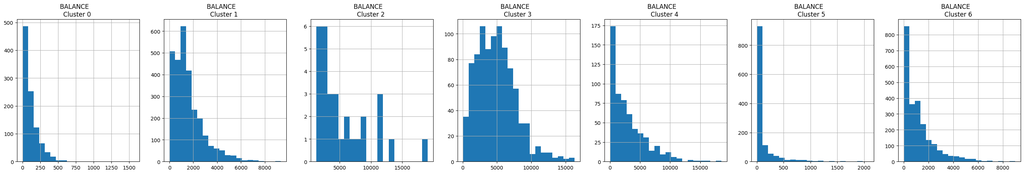

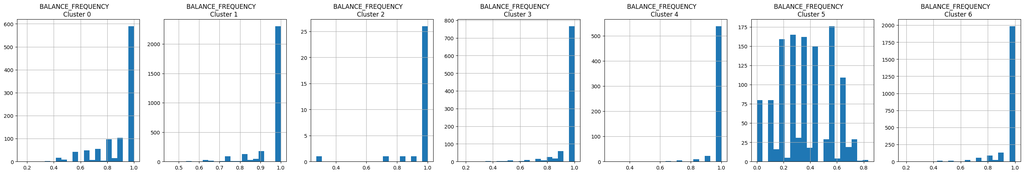

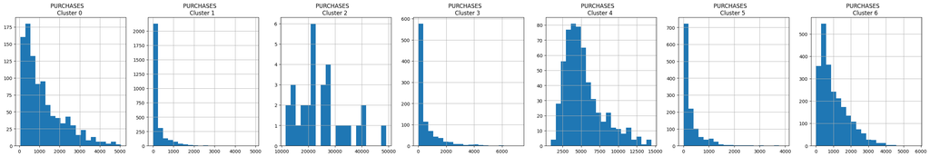

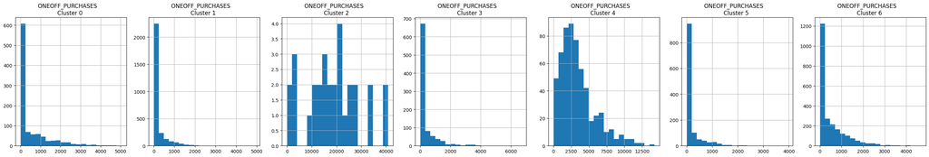

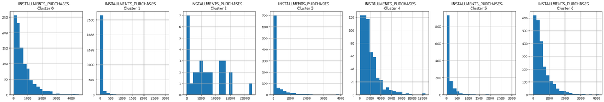

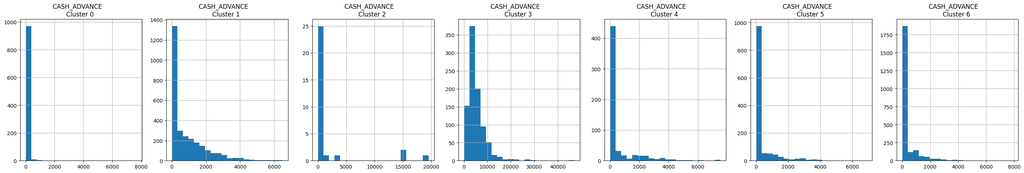

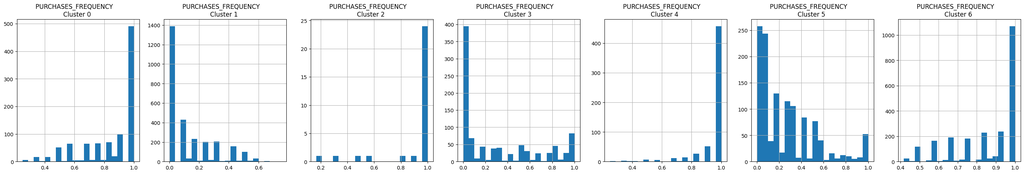

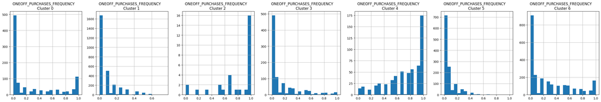

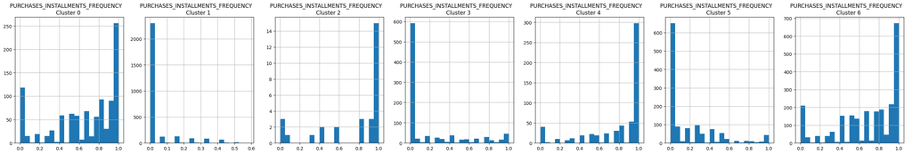

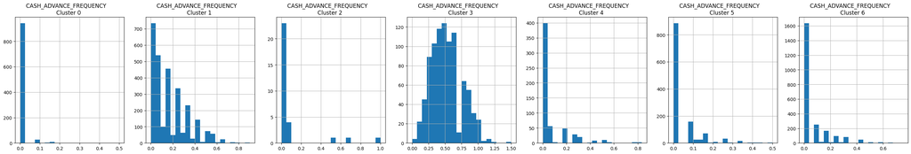

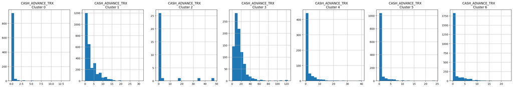

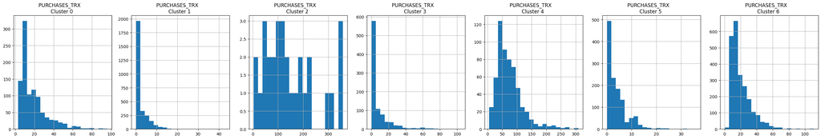

[5 more figures not shown]

```python
for i in df.columns:
  plt.figure(figsize = (35, 5))
  for j in range(7):
    plt.subplot(1,7,j+1)
    cluster = df_cluster[df_cluster['cluster'] == j]
    cluster[i].hist(bins = 20)
    plt.title('{}    \nCluster {} '.format(i,j))

  plt.show()
```

Cluster 0 can be described as regular users who have controlled spending habits. They keep a low balance, around $119, but have a high balance frequency of 0.89, which shows they manage their credit card balance regularly. They make moderate purchases, roughly $1,189, which are split between one-off purchases of about $524 and installment purchases around $665. They use very little cash advance, just about $35, and their cash advance frequency is almost negligible at 0.006. They have a high purchase frequency of 0.85, meaning they use their cards regularly. With a moderate credit limit of around $4,670, they make regular payments of about $1,293 and keep their minimum payment requirement low at $177. A high percentage of their full payment, 0.79, suggests they pay off their balances regularly. We could call these customers "Responsible Users" because they use their credit cards frequently but manage their balances well and often pay in full. They are ideal candidates for rewards programs and incentives for regular use.

Cluster 1 has low activity but is dependent on cash advances. They have a moderate balance of about $1,568 and a high balance frequency of 0.96, which shows they keep their balance stable. However, their purchases are very low, only around $222, and they don't use their card for purchases often, with a low purchase frequency of 0.13. They have high cash advance usage, approximately $863, and they take cash advances relatively frequently, with a frequency of 0.17. They rarely pay off their balance in full, as indicated by their very low percentage of full payment at 0.02. They have a moderate credit limit of about $3,299 and low overall payments of around $976. We could name this group "Cash Advance Reliant" since they depend more on cash advances rather than purchases. They might benefit from products offering lower fees for cash advances or financial counseling to reduce their reliance on them.

Cluster 2 consists of high spenders with maximum engagement. These customers keep a very high balance, around $5,567, and also have a high balance frequency of 0.96. They make extremely high purchases, about $24,958, with significant amounts in one-off purchases of $18,187 and installment purchases of around $6,771. Their cash advance usage is moderate, at about $1,859, with a frequency of 0.08. They use their cards often, with a purchase frequency of 0.91, and have a relatively high percentage of full payment at 0.48. Their credit limit is high at $15,570, and they make large payments, averaging $25,178. This group can be named "Affluent High Spenders" because they are top-tier customers who spend heavily and use their credit cards for large transactions. They should be targeted with premium offers, high-value rewards, and exclusive services.

Cluster 3 represents high cash advance users with a low purchase frequency. These customers have a high balance of around $4,927 and a high balance frequency of 0.97. They make low purchases, roughly $545, but have very high cash advance usage at about $5,151 and a high cash advance frequency of 0.52. Their purchase frequency is low at 0.30, and they have a very low percentage of full payment at 0.04. Their credit limit is moderate, about $8,086, but they have relatively high minimum payments, around $2,075. This cluster can be called "Cash Advance Heavy Users" because they rely heavily on cash advances and might be considered higher-risk customers. Products that help manage cash flow or reduce cash advance fees could be beneficial for them.

Cluster 4 is made up of moderate spenders who have balanced usage. They have a moderate balance of about $3,050 and a very high balance frequency of 0.98. They make high purchases, around $5,260, which are balanced between one-off purchases of $3,372 and installment purchases of about $1,889. Their cash advance usage is low, around $525, with a low frequency of 0.07. They have a high purchase frequency of 0.95 and make moderate payments, roughly $4,899. Their percentage of full payment is low at 0.23. We could name this group "Balanced Spenders" since they maintain a balanced approach to spending, with both one-off and installment purchases. They could be targeted with flexible rewards programs and promotional offers for regular purchases and installments.

Cluster 5 consists of inactive low spenders with minimal engagement. They have a very low balance, around $118, and a low balance frequency of 0.36. They make low purchases, about $305, and their purchase frequency is very low, at 0.25. Their cash advance usage is moderate, at around $357, with a low frequency of 0.04. They have a low credit limit of about $3,612 and low payments of roughly $1,076. Their percentage of full payment is also low, at 0.17. This cluster can be named "Dormant Users" because these are inactive customers who rarely use their cards. They could be encouraged to use their cards more frequently with special offers, introductory rewards, or waived fees.

Cluster 6 includes regular spenders who have controlled usage. They maintain a low to moderate balance, around $1,195, and a very high balance frequency of 0.97. They make moderate purchases of about $1,052, with a mix of one-off purchases of $499 and installment purchases of around $554. They have low cash advance usage, roughly $316, and a low frequency of 0.06. They have a high purchase frequency of 0.86 and low cash advance transactions of about 1.16. Their credit limit is moderate, around $3,737, and their payments are also moderate, approximately $1,215. We could name this group "Regular and Controlled Spenders" because these customers make regular purchases and maintain good control over their usage. They could benefit from cashback offers, loyalty programs, and incentives for regular use.